# Multivariate Analysis | Part 2

#### Pairwise feature combination of `kmeans2`

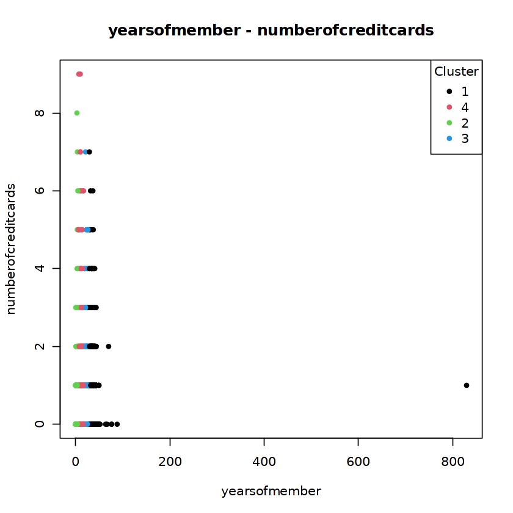

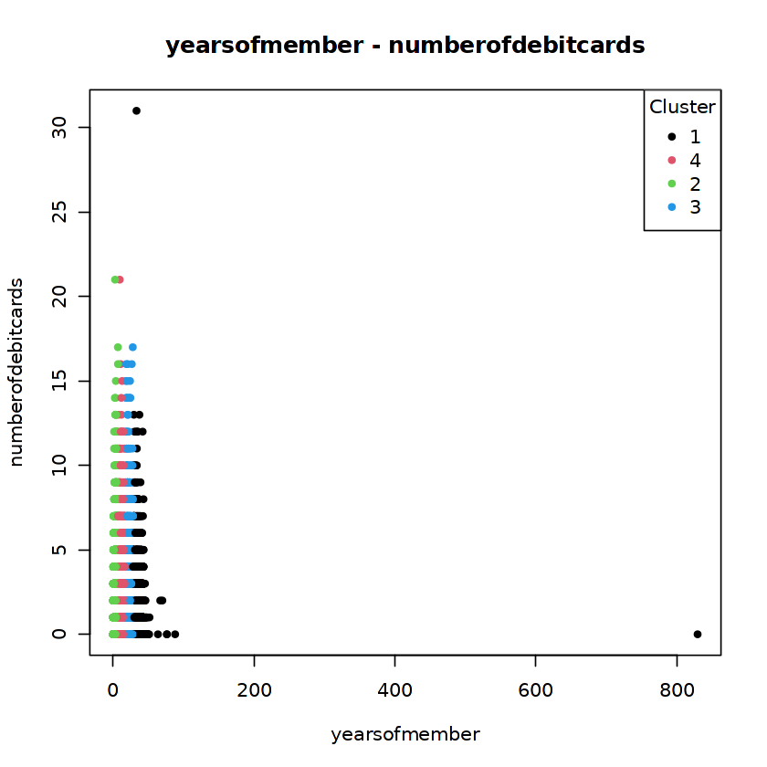

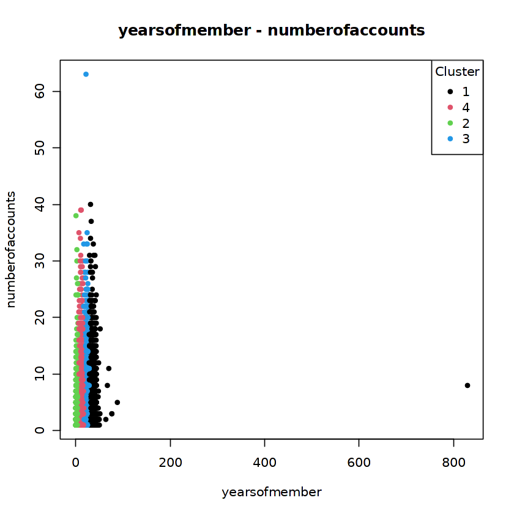

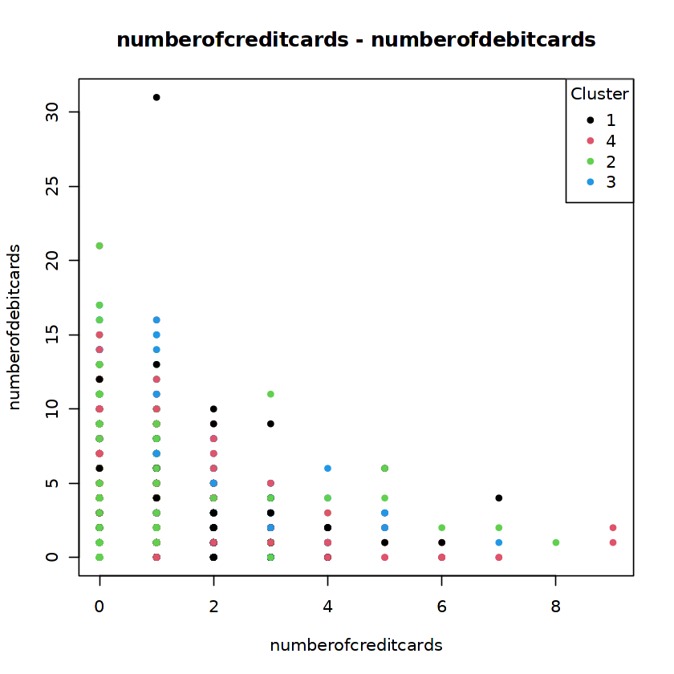

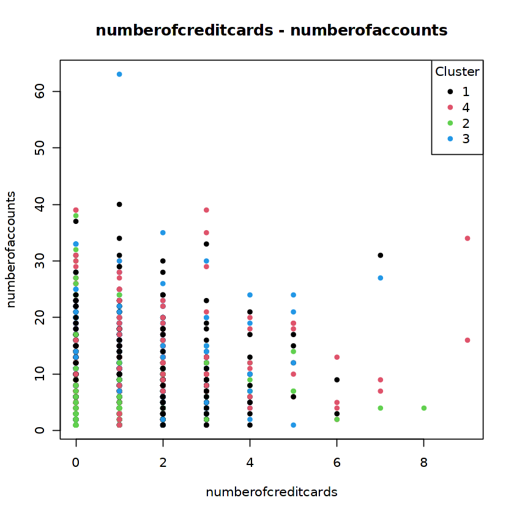

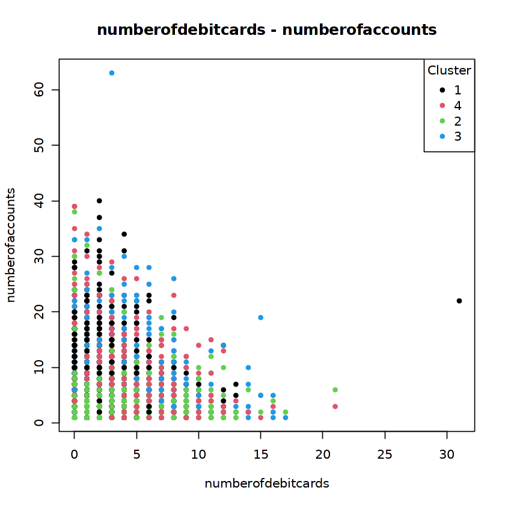

```r
# Define a function to plot pairwise combinations of features
plot_pairwise_clusters <- function(df, cluster_assignments, title) {
  # Get unique cluster assignments
  clusters <- unique(cluster_assignments)

  # Set up the plot layout
  par(mfrow=c(1,1))

  # Iterate over pairwise combinations of features
  for (i in 1:(ncol(df) - 1)) {
    for (j in (i + 1):ncol(df)) {
      # Plot each pairwise combination
      plot(df[, i], df[, j], col = cluster_assignments, pch = 20,
           xlab = names(df)[i], ylab = names(df)[j],
           main = paste(names(df)[i], "-", names(df)[j]))
      legend("topright", legend = clusters, col = 1:length(clusters), pch = 20, title = "Cluster")
    }
  }
}

# plot pairwise combinations of features colored by cluster assignment for kmeans2
plot_pairwise_clusters(df_KMeans2, kmeans2$cluster_assignments)
```

#### Summary

We plot the pairwise combination of feature because we want to explore the relationship between different features within each cluster

**Note:** We color the pairwise plot with cluster assignment because

We want the patterns to be easily identified

To see if our semi-unsupervised algorithm has successfully identified meaningful patterns in our data

It makes it easier to interpret the results of our clustering by providing a visual representation of how the data is partitioned into clusters based on different features.

### Cluster Density Plot

#### Cluster density plot for `kmeans1` using cluster assignments and centers

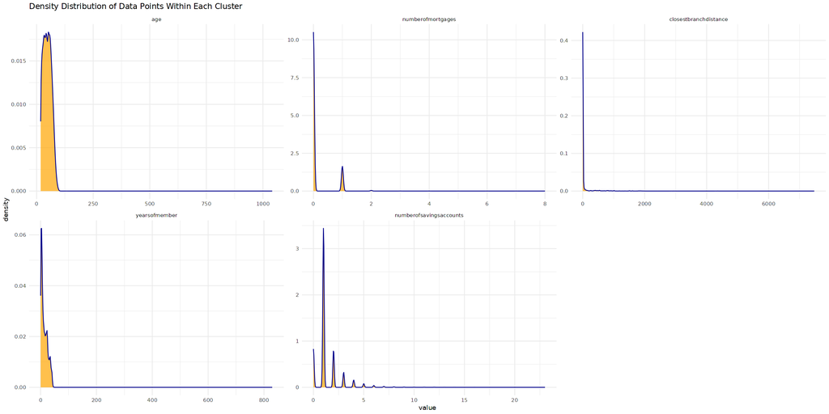

```r
# Function to plot density distribution within each cluster
plot_cluster_density <- function(cluster_assignments, cluster_centers, data) {
  # Add cluster assignments to the original data
  data_with_clusters <- cbind(data, cluster = factor(cluster_assignments))

  # Melt the data for ggplot
  data_melted <- reshape2::melt(data_with_clusters, id.vars = "cluster")

  # Set plot size
  options(repr.plot.width=20, repr.plot.height=10) # Adjust width and height as needed

  # Plot density distribution of each cluster
  ggplot(data_melted, aes(x = value, fill = cluster)) +
    geom_density(fill = "orange", color = "darkblue", alpha = 0.7) +
    facet_wrap(~ variable, scales = "free") +
    theme_minimal() +
    labs(title = "Density Distribution of Data Points Within Each Cluster")
}

# Extract cluster assignments and cluster centers for kmeans1
cluster_assignments <- kmeans1$cluster_assignments
cluster_centers <- kmeans1$cluster_centers

# Data frame used for clustering
data <- df_KMeans1

# Plot density distribution within each cluster
plot_cluster_density(cluster_assignments, cluster_centers, data)
```

#### Summary

We plot the density distribution of data points within each cluster to visualize the concentration of data points within each cluster

From the result of plotting `kmeans1`, we see that it closely reflects the information provided by our pairwise feature plot.

Based on this information, I choose to not plot the others.

### Parallel Coordinates Plot

#### Plot Parallel Coordinates of `kmeans1` clustering result

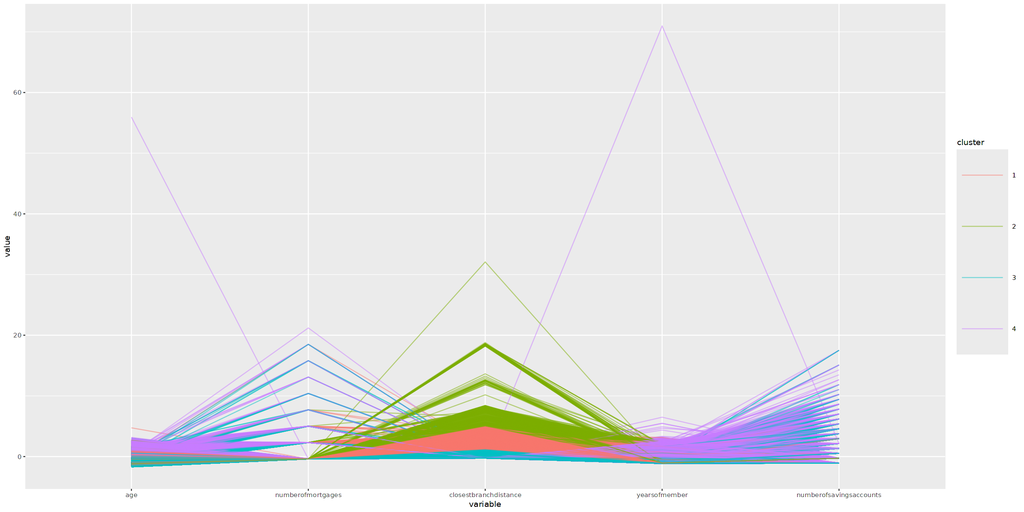

```r
# Function to plot parallel coordinates
plot_parallel_coordinates <- function(kmeans_result, data) {
  # Extract cluster assignments from the kmeans_result list
  cluster_assignments <- kmeans_result$cluster_assignments

  # Add cluster assignments to the original data
  data_with_clusters <- cbind(data, cluster = factor(cluster_assignments))

  # Plot parallel coordinates
  ggparcoord(data_with_clusters, columns = 1:(ncol(data_with_clusters) - 1),
             groupColumn = ncol(data_with_clusters), alphaLines = 0.5) +
    theme(legend.key.size = unit(5, "lines"))
}

# Extract cluster assignments for kmeans1
cluster_assignments <- kmeans1$cluster_assignments

# Data frame used for clustering
data <- df_KMeans1

# Plot parallel coordinates
plot_parallel_coordinates(kmeans1, data)
```

#### Explanation

The reasoning for using the parallel plot is to visualize the distribution/overall pattern of each cluster across multiple variables

The line connects each data point value across all the axes and helps us to see relationships.

The desire is to identify potential trends, understand similarities and structure of the data

## Principal Component Analysis (PCA)

### Perform PCA On Unclustered Data

```r
# List of data frames and their names
df_list <- list(df_KMeans1 = df_KMeans1, df_KMeans2 = df_KMeans2,
                df_KMeans3 = df_KMeans3, df_KMeans4 = df_KMeans4)

# Initialize an empty list to store PCA results
pca_results <- list()

# Perform PCA on each dataframe and store the results
for (name in names(df_list)) {
  pca_results[[name]] <- prcomp(df_list[[name]], scale. = TRUE)
}

# Display summary of each PCA result
for (name in names(pca_results)) {
  cat("Summary of PCA result for", name, ":\n")
  print(summary(pca_results[[name]]))
  cat("\n")
}
```

```
Summary of PCA result for df_KMeans1 :
Importance of components:
                          PC1    PC2    PC3    PC4    PC5
Standard deviation     1.2317 1.0471 0.9749 0.9453 0.7363
Proportion of Variance 0.3034 0.2193 0.1901 0.1787 0.1084
Cumulative Proportion  0.3034 0.5227 0.7128 0.8916 1.0000

Summary of PCA result for df_KMeans2 :
Importance of components:
                          PC1    PC2    PC3    PC4
Standard deviation     1.3092 0.9687 0.8750 0.7630
Proportion of Variance 0.4285 0.2346 0.1914 0.1455
Cumulative Proportion  0.4285 0.6631 0.8545 1.0000

Summary of PCA result for df_KMeans3 :
Importance of components:
                          PC1    PC2    PC3     PC4
Standard deviation     1.3633 1.0185 0.9513 0.44605
Proportion of Variance 0.4647 0.2593 0.2263 0.04974
Cumulative Proportion  0.4647 0.7240 0.9503 1.00000

Summary of PCA result for df_KMeans4 :
Importance of components:
                          PC1    PC2    PC3    PC4
Standard deviation     1.1661 0.9951 0.9144 0.9022
Proportion of Variance 0.3399 0.2475 0.2090 0.2035
Cumulative Proportion  0.3399 0.5875 0.7965 1.0000
```

### Visualize Correlation Circle and Individuals Plot Side-by-Side

#### Explanation

By analyzing these plots, we can gain insights into the structure of the data and the relative importance of the variables in explaining the variance in the data.

This can be particularly useful for identifying the most important features or variables in the dataset

It can also help us in understanding the relationships between the variables and the principal components.

```
 Visualizing PCA results for df_KMeans1 :
```

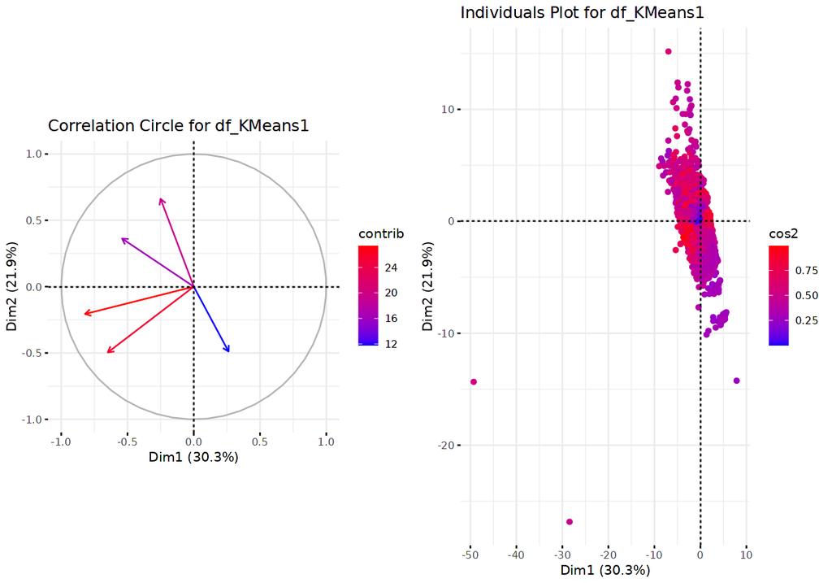

```
 Visualizing PCA results for df_KMeans2 :
```

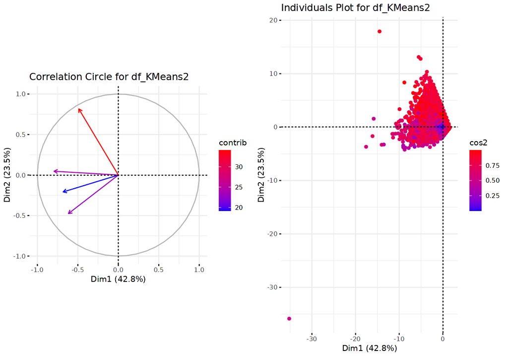

```
 Visualizing PCA results for df_KMeans3 :
```

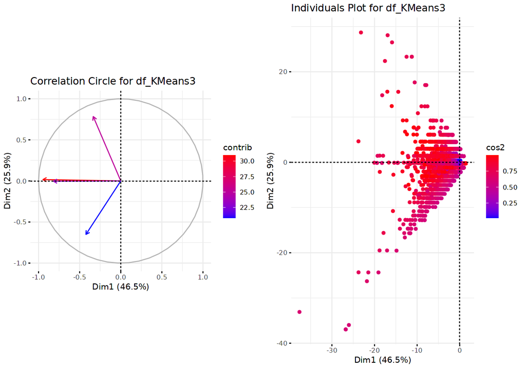

```
 Visualizing PCA results for df_KMeans4 :
```

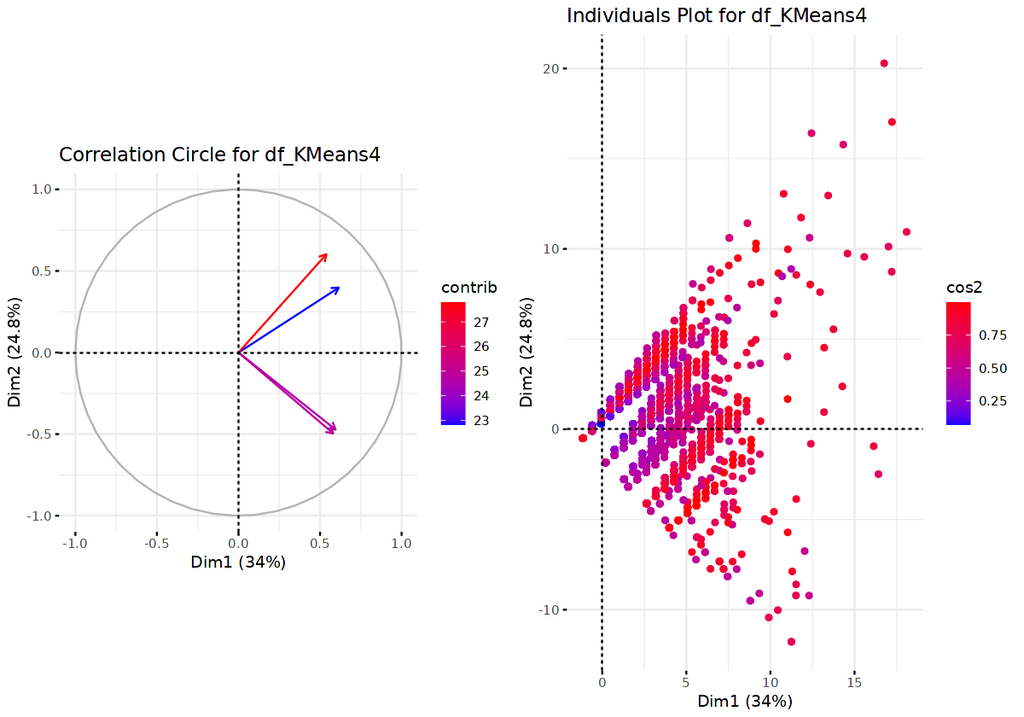

```r
# Create a loop of the `pca_results`
for (name in names(pca_results)) {

  pca_result <- pca_results[[name]]

  # Get variable names
  var_names <- colnames(pca_result$rotation)

  # Get PC names
  pc_names <- paste("PC", seq_len(ncol(pca_result$x)))

  # Correlation circle plot
  corr_circle <- fviz_pca_var(pca_result, geom = "arrow", col.var = "contrib",
                              gradient.cols = c("blue", "red"), repel = TRUE,
                              title = paste("Correlation Circle for", name))

  # Individuals plot
  individuals_plot <- fviz_pca_ind(pca_result, geom = "point", col.ind = "cos2",
                                   gradient.cols = c("blue", "red"),
                                   title = paste("Individuals Plot for", name))

  # Display the plots side by side using grid.arrange
  grid.arrange(corr_circle, individuals_plot, ncol = 2)

  cat("\n", "Visualizing PCA results for", name, ":\n")
}
```

#### Summary

**Correlation Circle Plot** helps us to identify the variables that are most strongly correlated with the principal components.

Variables with longer arrows are more strongly correlated with the principal components, and the direction of the arrows indicates the direction of the correlation.

**Individuals Plot** helps us to visualize the distribution of the data points (individuals) in the principal component space.

### Perform PCA on Clustered Data

**Note:** Using the result of the cluster profile will produce similar result but the plot is more chaotic

*The PCA is performed on each subset instead of on the entire dataset due to kernel crashing issues with anvil as well as disimilarities with the number of columns of matrices*

#### Perform PCA on `kmeans1` cluster centers

```
Importance of components:
                          PC1    PC2     PC3                   PC4
Standard deviation     1.8874 1.1015 0.47358 0.0000000000000006833
Proportion of Variance 0.7125 0.2427 0.04486 0.0000000000000000000
Cumulative Proportion  0.7125 0.9551 1.00000 1.0000000000000000000
```

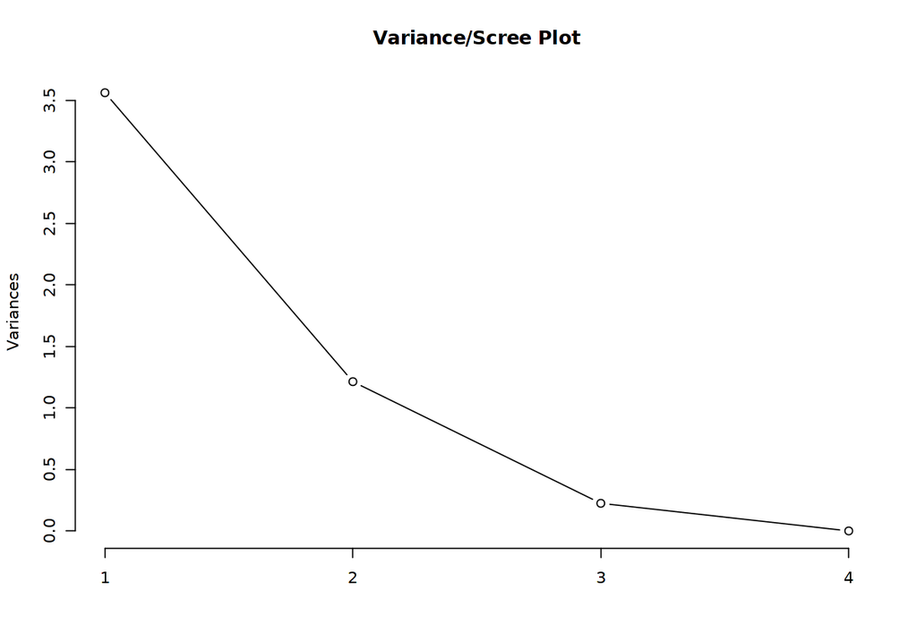

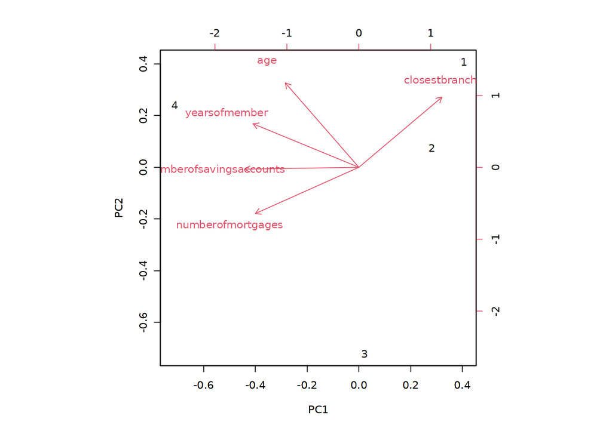

```r
# Perform PCA on `kmeans1`
pca_result <- prcomp(kmeans1$cluster_centers, scale. = TRUE)

# Summary of PCA results
summary(pca_result)

# Set plot size
options(repr.plot.width=10, repr.plot.height=7) # Adjust width and height as needed

# Scree plot
plot(pca_result, type = "l", main = "Variance/Scree Plot")

# Biplot
biplot(pca_result)
```

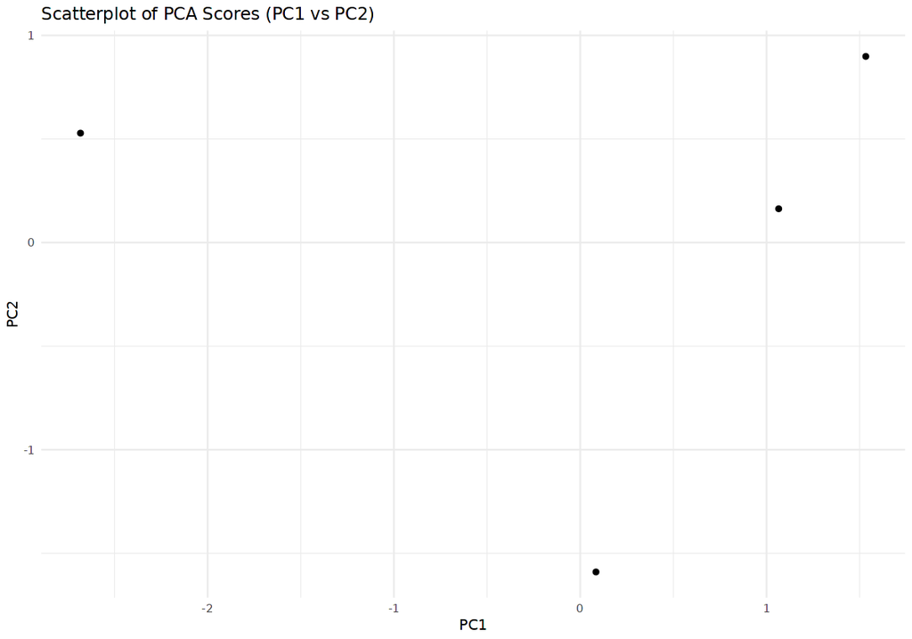

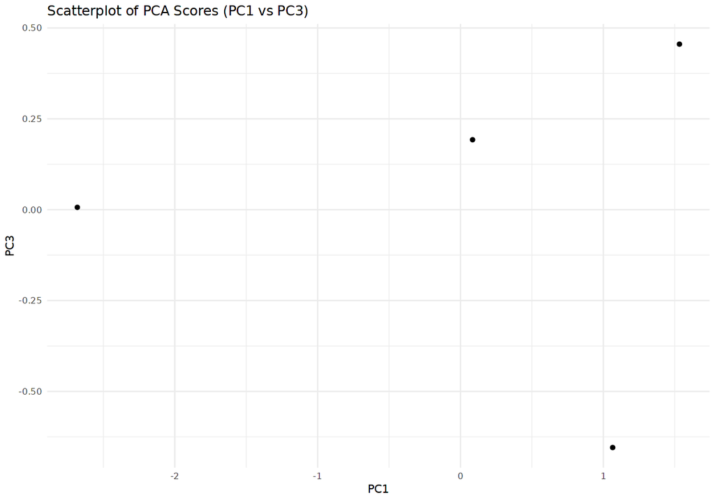

```r
library(ggplot2)

# Convert PCA result to data frame
pca_df <- as.data.frame(pca_result$x)

# Create scatterplot for PC1 vs PC2
p1 <- ggplot(pca_df, aes(x = PC1, y = PC2)) +
  geom_point() +
  labs(title = "Scatterplot of PCA Scores (PC1 vs PC2)",
       x = "PC1", y = "PC2") +
  theme_minimal()

print(p1)

# Create scatterplot for PC1 vs PC3
p2 <- ggplot(pca_df, aes(x = PC1, y = PC3)) +
  geom_point() +
  labs(title = "Scatterplot of PCA Scores (PC1 vs PC3)",
       x = "PC1", y = "PC3") +
  theme_minimal()

print(p2)
```

##### Summary

**Breakdown:**

PC1 has a standard deviation of 1.8874 and explains 71.25% of the total variance in the data.

PC2 has a standard deviation of 1.1015 and explains 24.27% of the total variance.

PC3 has a standard deviation of 0.47358 and explains 4.49% of the total variance.

Note that PC4 is an almost negligible 0% of total variance

We can see from the summary of the PCA analysis on kmeans1 that the first two principal components(i.e. PC1 and PC2) capture the most important sources of variation in the data.

Together with PC3, these 3 explain 100% of total variance and can represent the original dataset effectively without losing much information

**Therefore, the original features with the highest absolute values on PC1 and PC2 can be considered the most important features in the df_KMeans1 subset of the data**

#### Perform PCA on `kmeans2` cluster centers

```
Importance of components:
                          PC1    PC2     PC3                   PC4
Standard deviation     1.7588 0.9461 0.10655 0.0000000000000002062
Proportion of Variance 0.7734 0.2238 0.00284 0.0000000000000000000
Cumulative Proportion  0.7734 0.9972 1.00000 1.0000000000000000000
```

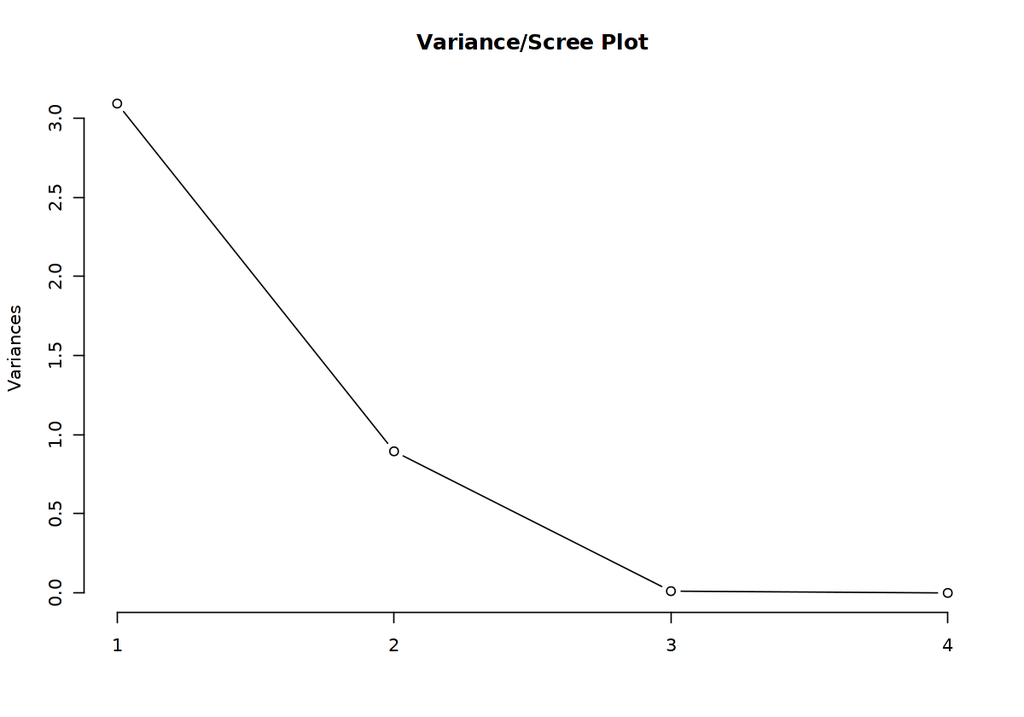

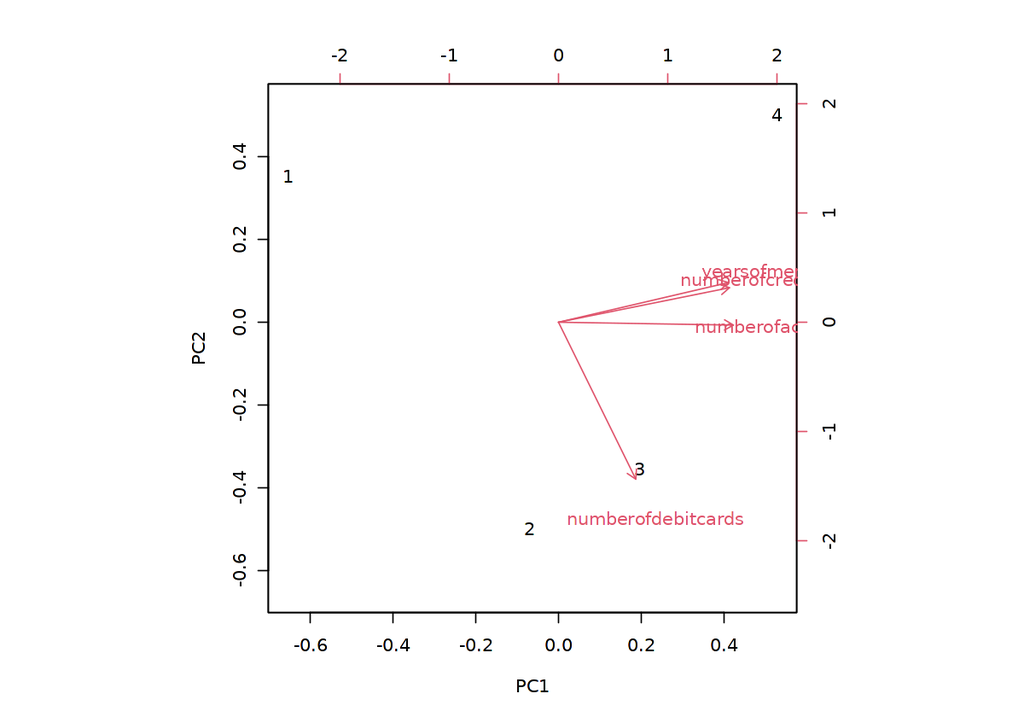

```r
# Perform PCA on `kmeans2`
pca_result <- prcomp(kmeans2$cluster_centers, scale. = TRUE)

# Summary of PCA results
summary(pca_result)

# Scree plot
plot(pca_result, type = "l", main = "Variance/Scree Plot")

# Biplot
biplot(pca_result)
```

#### Perform PCA on `kmeans3` cluster centers

```
Importance of components:
                          PC1     PC2     PC3                    PC4
Standard deviation     1.9704 0.28108 0.19651 0.00000000000000005124
Proportion of Variance 0.9706 0.01975 0.00965 0.00000000000000000000
Cumulative Proportion  0.9706 0.99035 1.00000 1.00000000000000000000
```

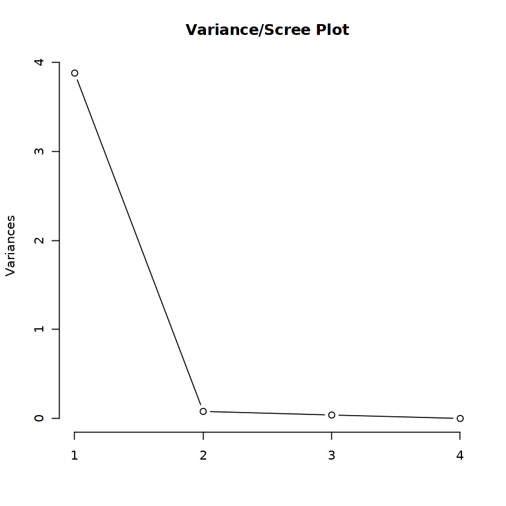

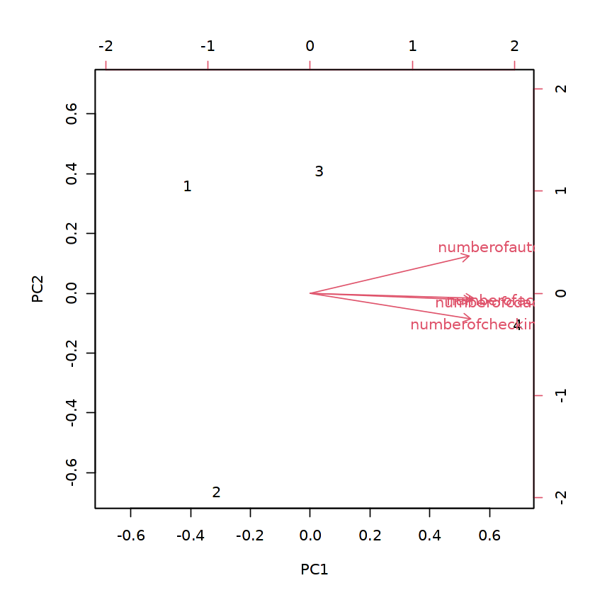

```r
# Perform PCA on `kmeans3`
pca_result <- prcomp(kmeans3$cluster_centers, scale. = TRUE)

# Summary of PCA results
summary(pca_result)

# Scree plot
plot(pca_result, type = "l", main = "Variance/Scree Plot")

# Biplot
biplot(pca_result)
```

#### Perform PCA on `kmeans4` cluster centers

```
Importance of components:
                          PC1    PC2     PC3                   PC4
Standard deviation     1.8174 0.8302 0.08835 0.0000000000000001001
Proportion of Variance 0.8257 0.1723 0.00195 0.0000000000000000000
Cumulative Proportion  0.8257 0.9980 1.00000 1.0000000000000000000
```

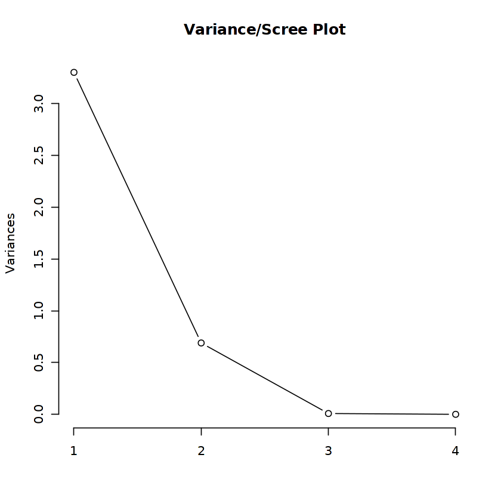

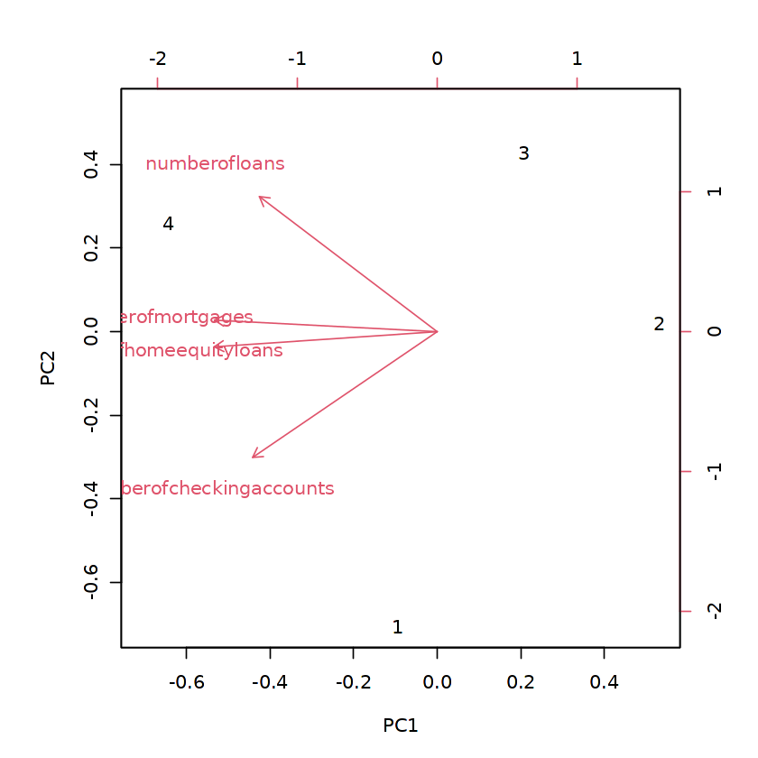

```r
# Perform PCA on `kmeans4`
pca_result <- prcomp(kmeans4$cluster_centers, scale. = TRUE)

# Summary of PCA results
summary(pca_result)

# Scree plot
plot(pca_result, type = "l", main = "Variance/Scree Plot")

# Biplot
biplot(pca_result)
```

### Perform DBSCAN on Unclustered Data

**Note:** The value you assign to the `eps` and the `minPts` will determine the result you get

The reason for performing this analysis is to identify noise or outliers in our data.

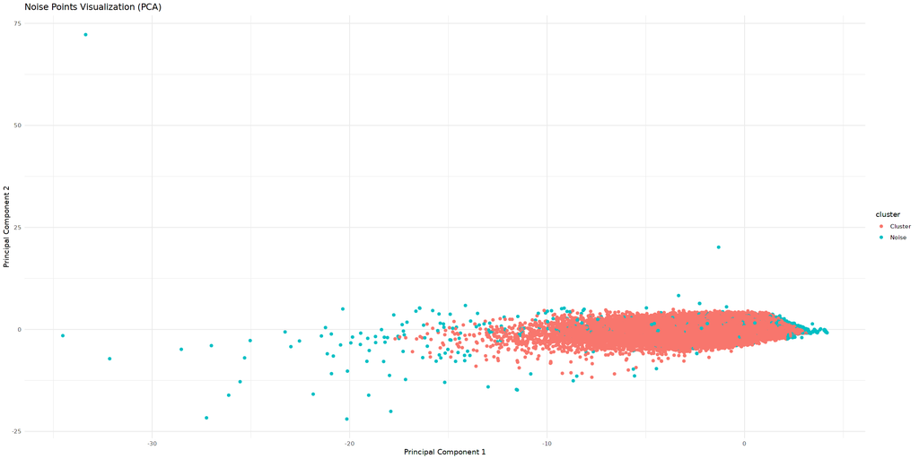

```r
# Combine the data frames into a single data frame
combined_df <- cbind(df_KMeans1, df_KMeans2, df_KMeans3, df_KMeans4)

# Perform DBSCAN clustering
dbscan_result <- dbscan(combined_df, eps = 10, minPts = 25)

# describe DBSCAN clustering result
#head(dbscan_result)

# Extract cluster labels from DBSCAN result
cluster_labels <- dbscan_result$cluster

# Check if there are any noise points
if (sum(cluster_labels == 0) > 0) {
  # Extract noise points
  noise_points_indices <- which(cluster_labels == 0)
  noise_points_df <- combined_df[noise_points_indices, ]

  # Perform PCA on the combined dataset
  pca_result <- prcomp(combined_df, scale. = TRUE)
  pca_df <- as.data.frame(pca_result$x)
  pca_df$cluster <- factor(ifelse(cluster_labels == 0, "Noise", "Cluster"))

  # Visualize noise points in the first two dimensions using PCA
  ggplot(pca_df, aes(x = PC1, y = PC2, color = cluster)) +
    geom_point() +
    labs(title = "Noise Points Visualization (PCA)",
         x = "Principal Component 1",
         y = "Principal Component 2") +
    theme_minimal()
} else {
  cat("No noise points (anomalies or outliers) detected.\n")
}
```

#### Summary

I determined that `eps = 10` and `minPts = 25` gave me the best visualization for the clusters and the noise points

Using lesser `eps` and `minPts` provided noisy visualization and in some cases the clusters were not visibly distinct from the noisy data points.

However, these can be adjusted in future works and might provide valuable insights into the underlying data structure.

We can also see that there are varying densities in the data points as the visualzations tapers towards the right.